# TCC

Iago

25/03/2021

### Metodologia

A Análise de variância por medidas repetidas é uma técnica paramétrica de comparação de médias em que as unidades experimentais são avaliadas periodicamente, fornecendo informações sobre tendências temporais do experimento, tais quais quanto tempo um tratamento leva para fazer efeito ou quanto tempo esse efeito dura. A repetida avaliação sobre uma mesma unidade experimental é mais eficiente para comparar a ação do tempo sobre os tratamentos, já que as medidas obtidas sob uma única unidade são menos variáveis do que as obtidas com várias unidades experimentais.

Nesse contexto, temos que a ANOVA por medidas repetidas investiga os dados sob dois aspectos: entre unidades experimentais e dentro das unidades experimentais. A análise entre unidades experimentais trata sobre a variância produzida pelo efeito da estrutura de tratamentos e blocos, chamados de condições do experimento. Já a análise dentro das unidades experimentais é focada na variância produzida pelas medidas repetidas, ou seja, proveniente das avaliações periódicas. Além disso, podemos separar a variância dentro das unidades experimentais em variância inerente às unidades experimentais e variância do erro.

A ANOVA por medidas repetidas requer que quatro suposições sobre a população sejam atendidas para garantir que o modelo proposto é adequado aos dados. São elas: normalidade, homocedasticidade, independência das observações e Simetria Composta.

A condição de Simetria Composta é definida como a situação onde as medidas repetidas possuem a mesma variância e covariância, resultando na seguinte matriz de covariâncias:

[figure not shown]

onde $m$ é o número de medidas repetidas.

É infactível assumir que essa rigorosa suposição seja cumprida pelos dados, visto que, intuitivamente, pares de observações de uma mesma unidade experimental pegos em tempos adjacentes tendem a ter uma maior correlação que observações medidas em uma distância temporal maior.

Por consequência, Huynh e Felt demonstraram que a condição necessária para a ANOVA por medidas repetidas é menos severa do que a Simetria Composta. Assim, para que a ANOVA por medidas repetidas seja válida, é necessário que a variância da diferença de todos os pares de medidas repetidas da matriz de covariâncias seja igual. Essa característica é denominada esfericidade e pode ser definida matematicamente por:

$$\begin{equation*}
\sigma^2_{(y_i-y_j)}=2\lambda\end{equation*}$$
ou
$$\begin{equation*}
\sigma_{ij}=\frac{\sigma_{ii}+\sigma_{jj}}{2}-\lambda
\end{equation*}$$

onde $\lambda$ é uma constante qualquer maior que 0.

Uma matriz de covariâncias que atenda a essa condição é conhecida como matriz do tipo H, ou seja,
$$\Sigma_{n\times n}= A_{n\times n} + A'_{n\times n} + \lambda I_{n\times n}.$$

Assim, utilizando a matriz de covariâncias estimada $S$ e uma matriz de contrastes ortogonais $C$, a hipótese de que a matriz de covariâncias populacional é uma matriz H esférica pode ser avaliada pelo teste de Mauchly.

Como demonstrado em Huynh 1970, ao multiplicar $\Sigma$ por uma matriz de contrastes normalizados C, na forma $C\Sigma C'$, $AC'= CA' = 0$. Portanto, em caso de esfricidade, $C\Sigma C'= \lambda I$.

A hipótese nula do teste de Mauschly para esfericidade é $H_0) C\Sigma C'= \lambda I$

A estatística do teste de esfericidade é $\chi^2=-\gamma \times ln(W)$, onde $\gamma=DFE-\frac{2m^2-3m+3}{6(m-1)}$.

DFE é o número de graus de liberdade do erro da análise de entre sujeitos. Para armadilhas, $DFE =8$ e para plantas $DFE=84$.

W é chamado de critério de Mauschly e é igual a $\frac{(m-1)^{m-1}\times |\textit{CSC'}|}{tr(\textit{CSC'})^{s-1}}$

A estatística do teste tem distribuição $\chi^2$ com $\frac{m(m-1)}{2}-1$ graus de liberdade sob a hipótese nula.

## Correções nos graus de liberdade

Um índice $\varepsilon$ sugerido por Box é capaz de medir o nível de esfericidade de uma matriz de covariâncias estimada. Essa medida varia de 0 a 1, sendo o valor máximo um indicativo de que os dados são perfeitamente esféricos. Quando existem indícios de que a hipótese de esfericidade não está sendo atendida, os graus de liberdade do teste $F$ da ANOVA por medidas repetidas são corrigidos multiplicando-os pelo índice $\varepsilon$. Portanto, a estatística do teste F da Análise de variância por medidas repetidas terá distribuição
$$\begin{equation*}
F \mathtt{\sim} F(\varepsilon\nu_1;\varepsilon\nu_2)
\end{equation*}$$
sob a hipótese nula, onde $\nu_1$ e $\nu_2$ indicam os graus de liberdade da distribuição $F$.

Baseando-se nessa abordagem, Greenhouse e Geisser; e Huynh e Felt e Lacoutre desenvolveram medidas de correção que utilizam os autovalores da matriz de covariâncias estimada. Assim, a correção de Greenhouse-Geisser é definida por: correção de Greenhouse-Geisser utiliza os valores da diagonal principal da matriz $CSC'$
$$\begin{equation*}
\hat{\varepsilon}_{gg}=\frac{\left(\sum_{i=1}^{m-1}\limits a_{ii}\right)^2}{(m-1)\sum_{i=1}^{m-1}\limits\sum_{j=1}^{m-1}\limits a_{ij}^2}
\end{equation*}$$

Onde $\a_{ii}$ são os valores da diagonal principal da matriz de variâncias e covariâncias estimada.  
Caso exista esfericidade na matriz de covariâncias estimadas, $V$ é igual a $m-1$. Por fim, a Correção de Huynh e Feldt Lacoutre é baseada na correção de Greenhouse-Geisser e é aplicada apenas quando existem fatores entre sujeitos, tais como o tratamento e os blocos.

$$\begin{equation*}
\hat{\varepsilon}_{hfl}=\frac{(DFE+1)\times(m-1)\hat{\varepsilon}_{gg}-2}{(m-1)\times(DFE-(m-1)\hat{\varepsilon}_{gg})}.
\end{equation*}$$

### Modelagem

Estou trabalhando com um modelo Split-plot, tal como sugeriu o livro do KUEHL, na forma:
$$\begin{equation*}
Y_{ijk}= \mu +\tau_i + \beta_j + d_{ij} + m_k + (m\tau)_{ik} +(m\beta)_{jk}+\varepsilon_{ijk},
\end{equation*}$$
para as armadilhas.

- $ _i $ é o efeito dos tratamentos
- $\beta_j$ o efeito dos blocos
- $d_{ij}$ o erro 1
- $m_k$ o efeito das medidas repetidas
- $(m\tau)_{ik}$ a interação entre as medidas repetidas e os tratamentos
- $(m\beta)_{jk}$ a interação entre as medidas repetidas e os blocos
- $\varepsilon_{ijk}$ o erro 2.

Ao fazer a estimativa de parâmetros, tal qual eu fazia na aula de delineamento, utilizando $tapply$, muitas vezes eu obtenho valores preditos negativos, o que não é condizente com a natureza do estudo. Por exemplo, com os dados de armadilhas:

```r
mu <- mean(moscab)
taus <- tapply(moscab,trat,mean)-mean(moscab)
betas <- tapply(moscab,bloco,mean)-mean(moscab)
semanas <- tapply(moscab,semana,mean)-mean(moscab)
int_semana_trat <- tapply(moscab,semana:trat,mean)-mean(moscab)
int_semana_bloco <- tapply(moscab,semana:bloco,mean)-mean(moscab)
```

para o valor estimado da primeira observação do tratamento 1, bloco 1 e semana 1 das armadilhas temos:

```r
mu+taus[1]+betas[1]+semanas[1]+int_semana_bloco[1]+int_semana_trat[1]
```

```
##         1
## -1617.089
```

Utilizando outra combinação de variáveis, temos os valores fornecidos pelo SAS e pelo R.

```r
X1 <- tapply(moscab,semana,mean)
X2 <- tapply(moscab,semana:trat,mean)-rep(tapply(moscab,semana,mean),each=5)
X3 <- tapply(moscab,semana:bloco,mean)-rep(tapply(moscab,semana,mean),each=3)

X1[1]+X2[1]+X3[1]
```

```
##   1
## 322
```

Não sei o porquê desse erro.

## Dados brutos

Estimativa dos parâmetros do modelo:

```r
m <- 9 #quantidade de medidas repetidas
tapply(moscab,semana,mean)
```

```
##         1         2         3         4         5         6         7         8
##  276.5333  243.8000  385.4667  608.1333 2038.4000 2309.0000 2011.4000 2905.4667
##         9
## 2524.6667
```

```r
tapply(moscab,semana:trat,mean)-rep(tapply(moscab,semana,mean),each=5)
```

```
##         1:1         1:2         1:3         1:4         1:5         2:1
##    68.80000    66.46667  -141.86667    41.80000   -35.20000    39.86667
##         2:2         2:3         2:4         2:5         3:1         3:2
##    59.20000  -135.13333   -27.80000    63.86667   -90.13333   127.86667
##         3:3         3:4         3:5         4:1         4:2         4:3
##  -218.46667    33.20000   147.53333   192.86667    81.86667  -356.46667
##         4:4         4:5         5:1         5:2         5:3         5:4
##   123.20000   -41.46667   280.60000   174.93333 -1279.73333   300.60000
##         5:5         6:1         6:2         6:3         6:4         6:5
##   523.60000  1133.66667  -547.00000  -141.66667 -1241.66667   796.66667
##         7:1         7:2         7:3         7:4         7:5         8:1
##   444.93333   893.26667 -1466.06667  -123.73333   251.60000   486.86667
##         8:2         8:3         8:4         8:5         9:1         9:2
##  -161.46667   -12.80000  -266.46667   -46.13333  1390.33333  -481.33333
##         9:3         9:4         9:5
##  -506.00000  -872.33333   469.33333
```

```r
tapply(moscab,semana:bloco,mean)-rep(tapply(moscab,semana,mean),each=3)
```

```
##         1:1         1:2         1:3         2:1         2:2         2:3
##   -23.33333    43.46667   -20.13333   -39.20000   -87.60000   126.80000
##         3:1         3:2         3:3         4:1         4:2         4:3
##  -142.66667    57.73333    84.93333  -131.73333   106.46667    25.26667
##         5:1         5:2         5:3         6:1         6:2         6:3
## -1003.80000  -174.00000  1177.80000   333.00000 -1100.80000   767.80000
##         7:1         7:2         7:3         8:1         8:2         8:3
##  -803.20000    50.00000   753.20000  1368.13333 -1467.86667    99.73333
##         9:1         9:2         9:3
##   671.33333  -814.06667   142.73333
```

Valores preditos e Resíduos (cada coluna indica uma semana):

```r
pred_res <- read.xlsx("/cloud/project/pred_res_armadilhas.xlsx")
preditos <- pred_res[,c(12:20)]
preditos
```

```
##       pred1     pred2     pred3    pred4     pred5      pred6     pred7
## 1  322.0000 244.46667 152.66667 669.2667 1315.2000 3775.66667 1653.1333
## 2  388.8000 196.06667 353.06667 907.4667 2145.0000 2341.86667 2506.3333
## 3  325.2000 410.46667 380.26667 826.2667 3496.8000 4210.46667 3209.5333
## 4  319.6667 263.80000 370.66667 558.2667 1209.5333 2095.00000 2101.4667
## 5  386.4667 215.40000 571.06667 796.4667 2039.3333  661.20000 2954.6667
## 6  322.8667 429.80000 598.26667 715.2667 3391.1333 2529.80000 3657.8667
## 7  111.3333  69.46667  24.33333 119.9333 -245.1333 2500.33333 -257.8667
## 8  178.1333  21.06667 224.73333 358.1333  584.6667 1066.53333  595.3333
## 9  114.5333 235.46667 251.93333 276.9333 1936.4667 2935.13333 1298.5333
## 10 295.0000 176.80000 276.00000 599.6000 1335.2000 1400.33333 1084.4667
## 11 361.8000 128.40000 476.40000 837.8000 2165.0000  -33.46667 1937.6667
## 12 298.2000 342.80000 503.60000 756.6000 3516.8000 1835.13333 2640.8667
## 13 218.0000 268.46667 390.33333 434.9333 1558.2000 3438.66667 1459.8000
## 14 284.8000 220.06667 590.73333 673.1333 2388.0000 2004.86667 2313.0000
```

[output cut: 17 more lines]

```r
residuos <- as.matrix(pred_res[,21:29])
residuos
```

```
##             r1         r2          r3         r4          r5         r6
## 1   -28.000000  -72.46667   78.333333  -72.26667  -355.20000 -2147.6667
## 2   -18.800000  -57.06667  -47.066667 -195.46667  -622.00000  1426.1333
## 3    46.800000  129.53333  -31.266667  267.73333   977.20000   721.5333
## 4   230.333333  196.20000  278.333333  135.73333   343.46667  1013.0000
## 5   -60.466667  -33.40000  -42.066667   23.53333   640.66667  -467.2000
## 6  -169.866667 -162.80000 -236.266667 -159.26667  -984.13333  -545.8000
## 7   -27.333333   24.53333   87.666667   47.06667   844.13333  1587.6667
## 8     9.866667  118.93333   -9.733333   44.86667    96.33333  -277.5333
## 9    17.466667 -143.46667  -77.933333  -91.93333  -940.46667 -1310.1333
## 10 -106.000000  -18.80000 -128.000000  -30.60000  -185.20000   491.6667
## 11  133.200000   67.60000  414.600000  152.20000  1223.00000   750.4667
## 12  -27.200000  -48.80000 -286.600000 -121.60000 -1037.80000 -1242.1333
## 13  -69.000000 -129.46667 -316.333333  -79.93333  -647.20000  -944.6667
## 14  -63.800000  -96.06667 -315.733333  -25.13333 -1338.00000 -1431.8667
```

[output cut: 17 more lines]

Matriz de covriâncias estimada e matriz 8x9 de contrastes fornecidas pelo SAS:

```r
S<- t(residuos)%*%residuos #matriz de covariâncias
S
```

```
##          r1        r2         r3        r4         r5         r6         r7
## r1 146226.9  139363.9   302659.1  120569.5   840785.9   906134.1   759628.1
## r2 139363.9  210890.8   357869.1  175782.9  1357972.7  1562776.1  1147762.7
## r3 302659.1  357869.1  1027923.1  281940.3  3128577.3  3273882.9  2911551.1
## r4 120569.5  175782.9   281940.3  229081.9  1369771.7  1077183.5   962642.7
## r5 840785.9 1357972.7  3128577.3 1369771.7 13328418.9 13073204.1 10306466.1
## r6 906134.1 1562776.1  3273882.9 1077183.5 13073204.1 23961820.3 13333049.5
## r7 759628.1 1147762.7  2911551.1  962642.7 10306466.1 13333049.5 10282750.3
## r8 139071.7 -214365.1 -1760404.5 -120192.5 -4527593.7  4902581.6 -3046885.6
## r9 496633.9  554094.9   747432.3  730132.1  4069791.7 10779853.8  4905311.6
##            r8         r9
## r1   139071.7   496633.9
## r2  -214365.1   554094.9
## r3 -1760404.5   747432.3
## r4  -120192.5   730132.1
## r5 -4527593.7  4069791.7
## r6  4902581.6 10779853.8
## r7 -3046885.6  4905311.6
## r8 24030957.5 10591337.1
## r9 10591337.1 10116553.1
```

```r
C <- as.matrix(read.xlsx("/cloud/project/contrastes_armadilhas.xlsx"))
C
```

```
##        semana1     semana2    semana3     semana4    semana5     semana6
## 1 -0.516397779 -0.38729833 -0.2581989 -0.12909944  0.0000000  0.12909944
## 2  0.531816024  0.13295401 -0.1519474 -0.32288830 -0.3798686 -0.32288830
## 3 -0.444949208  0.22247460  0.4131671  0.28603878  0.0000000 -0.28603878
## 4  0.312893109 -0.46933966 -0.2458446  0.20114557  0.4022911  0.20114557
## 5 -0.184900065  0.50847518 -0.1849001 -0.41602515  0.0000000  0.41602515
## 6  0.089893315 -0.38204659  0.4944132  0.02247333 -0.4494666  0.02247333
## 7 -0.034139437  0.20483662 -0.4779521  0.47795212  0.0000000 -0.47795212
## 8  0.008814765 -0.07051812  0.2468134 -0.49362683  0.6170335 -0.49362683
##      semana7     semana8     semana9
## 1  0.2581989  0.38729833 0.516397779
## 2 -0.1519474  0.13295401 0.531816024
## 3 -0.4131671 -0.22247460 0.444949208
## 4 -0.2458446 -0.46933966 0.312893109
## 5  0.1849001 -0.50847518 0.184900065
## 6  0.4944132 -0.38204659 0.089893315
## 7  0.4779521 -0.20483662 0.034139437
## 8  0.2468134 -0.07051812 0.008814765
```

Cálculo da matriz do teste de Mauschly

```r
CSC <- C%*%S%*%t(C) #Matriz 8x8 para teste de Mauschly
CSC
```

```
##               1          2          3          4             5          6
## 1 13716248.6442  2536811.8 -3267685.3 -1103511.3     -823.6276 -3723041.9
## 2  2536811.8372  9649959.1  2648520.5 -7127052.3 -9404009.5932 -4339408.3
## 3 -3267685.3497  2648520.5  2387631.1 -1613011.6 -3191884.0832  -370772.8
## 4 -1103511.3358 -7127052.3 -1613011.6  6150170.3  7601506.3992  3420581.7
## 5     -823.6276 -9404009.6 -3191884.1  7601506.4 10782999.7065  4954331.8
## 6 -3723041.8599 -4339408.3  -370772.8  3420581.7  4954331.8235  4107497.0
## 7 -6327340.2005  -895790.2  2091773.6   915967.9    33183.5461  2070801.5
## 8 -4369460.1720 -4552859.6   317339.2  3752627.9  3542202.1660  2566829.5
##             7          8
## 1 -6327340.20 -4369460.2
## 2  -895790.20 -4552859.6
## 3  2091773.57   317339.2
## 4   915967.86  3752627.9
## 5    33183.55  3542202.2
## 6  2070801.45  2566829.5
## 7  3845219.13  2820496.2
## 8  2820496.23  4405190.3
```

Teste de esfericidade:

```r
#################### teste de esfericidade

w <- ((m-1)**(m-1))*det(CSC)/(sum(diag(CSC))**(m-1)) #critério de mauschly
w #critério de Mauschly
```

```
## [1] 8.82849e-11
```

```r
gama <- 8-((2*81-27+3)/(48))
gama
```

```
## [1] 5.125
```

```r
chi <- -gama*log(w,base=exp(1))
chi
```

```
## [1] 118.6461
```

```r
1-pchisq(chi,(m*(m-1)/2-1))
```

```
## [1] 5.008982e-11
```

Com critério de Mauschly igual a 8.828e-11, gama igual a 5.125 e Estatística do teste 118.6461, o p-valor do teste de esfericidade é 5e-11. Portanto rejeita-se a hipótese de esfericidade da matriz de covariâncias e é necessário usar correções nos graus de liberdade para a análise dentre sujeitos.

Cálculo das correções de graus de liberdade:

```r
################### correções dos graus de liberdade
gg <- (sum(diag(CSC))**2)/((m-1)*sum((CSC)**2))
gg
```

```
## [1] 0.2777852
```

```r
hfl <- (9*(m-1)*gg-2)/((m-1)*(8-(m-1)*gg))
hfl
```

```
## [1] 0.3894386
```

Análise de Variância com medidas repetidas:

```r
modelo <- aov(moscab ~ (trat +bloco) * semana + Error(sujeito/semana), data=armadilhas)
summary(modelo)
```

```
##
## Error: sujeito
##           Df   Sum Sq Mean Sq F value Pr(>F)
## trat       4 14144351 3536088   1.000  0.461
## bloco      2 11941969 5970985   1.689  0.244
## Residuals  8 28289708 3536213
##
## Error: sujeito:semana
##              Df    Sum Sq  Mean Sq F value   Pr(>F)
## semana        8 140090486 17511311  20.360 6.49e-15 ***
## trat:semana  32  25450002   795313   0.925 0.586684
## bloco:semana 16  42111529  2631971   3.060 0.000761 ***
## Residuals    64  55044915   860077
## ---
## Signif. codes:  0 '***' 0.001 '**' 0.01 '*' 0.05 '.' 0.1 ' ' 1
```

Com esses valores, não é possível rejeitar a hipótese nula de que os tratamentos e blocos não influenciam na quantidade de moscas brancas apeendidas pelas armadilhas, o que pode ser confirmado pelos gráficos abaixo:

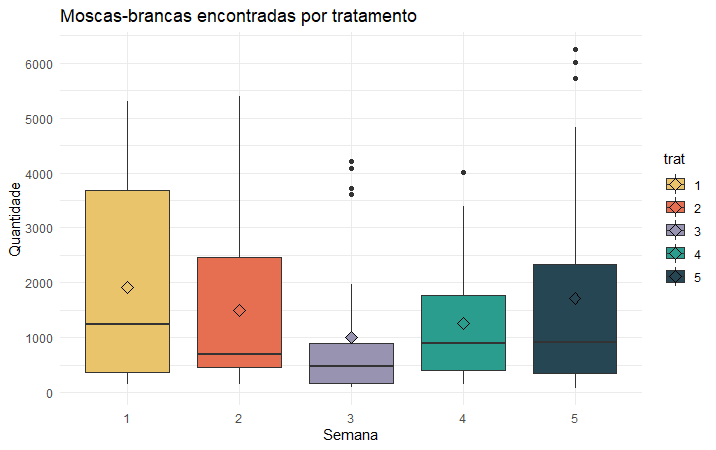

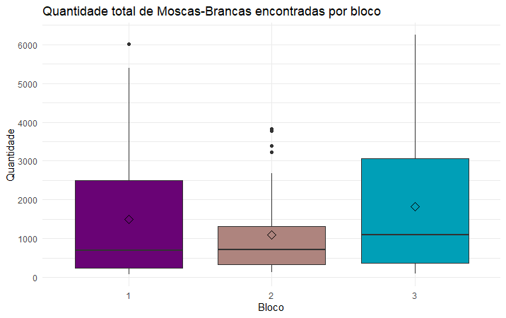

Em relação a análise dentre sujeitos, existem evidências para rejeitar a hipóotese de igualdade entre as semanas. Pelo gráfico boxplot abaixo, podemos verificar que com o decorrer do estudo a quantidade de moscas brancas apreendidas cresce.

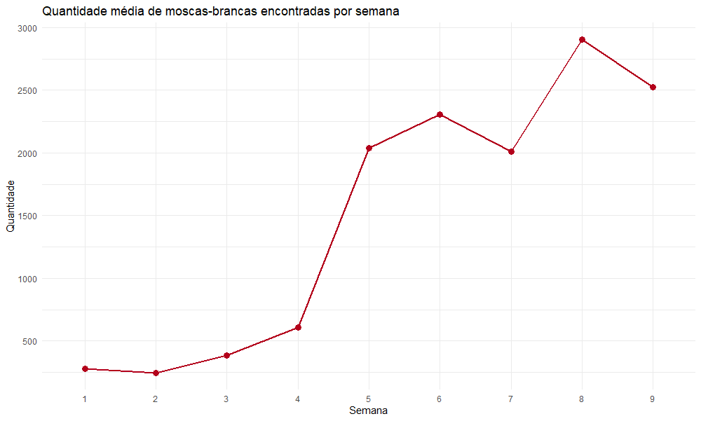

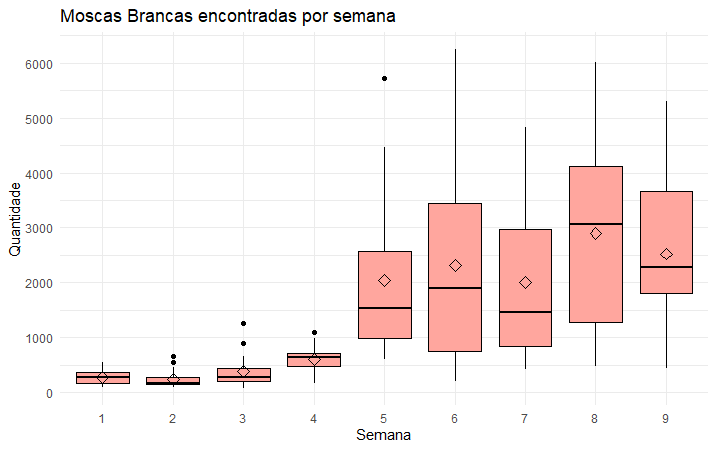

A interação entre o tempo e o tratamentos não é significativa, ou seja, no decorrer do estudo, as quantidades de moscas brancas apreendidas crescem igualmente entre as armadilhas de cada uma das variedades de tomateiro.

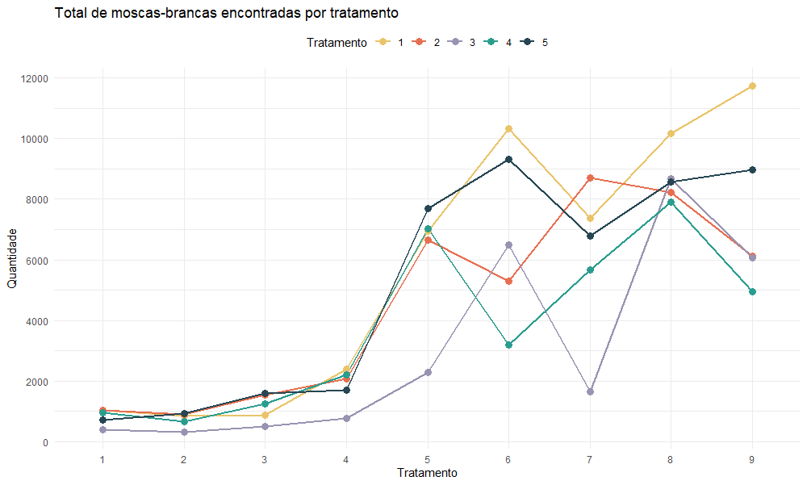

Já a interação entre o tempo e os blocos é significativa, portanto a quantidade de moscas apreendidas cresce de forma diferente entre as armadilhas de cada bloco.

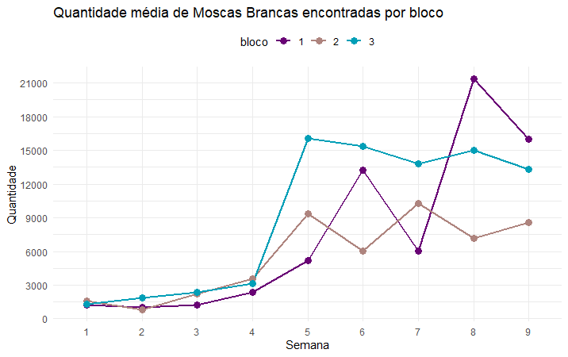

Vale ressaltar que os p-valores anteriores estão errados. Portanto, corrigindo-os, observa-se que não houve mudança nos resultados:

```r
#semana
1-pf(20.36,gg*8,gg*64)
```

```
## [1] 0.00001707371
```

```r
1-pf(20.36,hfl*8,hfl*64)
```

```
## [1] 0.0000005675271
```

```r
# semana: trat
1-pf(0.925,gg*32,gg*64)
```

```
## [1] 0.5262148
```

```r
1-pf(0.925,hfl*32,hfl*64)
```

```
## [1] 0.5402387
```

```r
#semana:bloco
1-pf(3.06,gg*16,gg*64)
```

```
## [1] 0.04019342
```

```r
1-pf(3.06,hfl*16,hfl*64)
```

```
## [1] 0.02100742
```

Análise de variância desconsiderando as medidas repetidas:

```r
modelo2 <- aov(moscab~trat+bloco)
summary(modelo2)
shapiro.test(modelo2$residuals)
```

```
##              Df    Sum Sq Mean Sq F value Pr(>F)
## trat          4  14144351 3536088   1.555 0.1902
## bloco         2  11941969 5970985   2.627 0.0762 .
## Residuals   128 290986640 2273333
## ---
## Signif. codes:  0 '***' 0.001 '**' 0.01 '*' 0.05 '.' 0.1 ' ' 1
##
##  Shapiro-Wilk normality test
##
## data:  modelo2$residuals
## W = 0.8899, p-value = 1.455e-08
```

Análises de variância por semana e teste subjacentes em caso de significância dos tratamentos:

```r
#Análise de variância por semanas
mod_semana1 <- aov(moscab~trat+bloco,data=armadilhas[semana=="1",])
summary(mod_semana1)
shapiro.test(mod_semana1$residuals)
```

```
##             Df Sum Sq Mean Sq F value Pr(>F)
## trat         4  96791   24198   1.324   0.34
## bloco        2  14196    7098   0.388   0.69
## Residuals    8 146227   18278
##
##  Shapiro-Wilk normality test
##
## data:  mod_semana1$residuals
## W = 0.93892, p-value = 0.369
```

```r
mod_semana2 <- aov(moscab~trat+bloco,data=armadilhas[semana=="2",])
summary(mod_semana2)
shapiro.test(mod_semana2$residuals)
```

```
##             Df Sum Sq Mean Sq F value Pr(>F)
## trat         4  84620   21155   0.803  0.556
## bloco        2 126443   63222   2.398  0.153
## Residuals    8 210891   26361
##
##  Shapiro-Wilk normality test
##
## data:  mod_semana2$residuals
## W = 0.93786, p-value = 0.3563
```

```r
mod_semana3 <- aov(moscab~trat+bloco,data=armadilhas[semana=="3",])
summary(mod_semana3)
shapiro.test(mod_semana3$residuals)
```

```
##             Df  Sum Sq Mean Sq F value Pr(>F)
## trat         4  285210   71302   0.555  0.702
## bloco        2  154503   77251   0.601  0.571
## Residuals    8 1027923  128490
##
##  Shapiro-Wilk normality test
##
## data:  mod_semana3$residuals
## W = 0.90826, p-value = 0.1273
```

```r
mod_semana4 <- aov(moscab~trat+bloco,data=armadilhas[semana=="4",])
summary(mod_semana4)
shapiro.test(mod_semana4$residuals) # trat significativo
TukeyHSD(mod_semana4)[1]
scottknott(armadilhas$moscab[semana=="4"],armadilhas$trat[semana=="4"],8,229082)
```

```
##             Df Sum Sq Mean Sq F value Pr(>F)
## trat         4 563598  140899    4.92 0.0268 *
## bloco        2 146636   73318    2.56 0.1382
## Residuals    8 229082   28635
## ---
## Signif. codes:  0 '***' 0.001 '**' 0.01 '*' 0.05 '.' 0.1 ' ' 1
##
##  Shapiro-Wilk normality test
##
## data:  mod_semana4$residuals
## W = 0.97485, p-value = 0.9222
##
## $trat
##           diff          lwr       upr      p adj
## 2-1 -111.00000  -588.332884 366.33288 0.92243624
## 3-1 -549.33333 -1026.666217 -72.00045 0.02483948
## 4-1  -69.66667  -546.999550 407.66622 0.98459715
## 5-1 -234.33333  -711.666217 242.99955 0.48557696
## 3-2 -438.33333  -915.666217  38.99955 0.07351092
## 4-2   41.33333  -435.999550 518.66622 0.99786811
## 5-2 -123.33333  -600.666217 353.99955 0.89195250
## 4-3  479.66667     2.333783 956.99955 0.04886478
## 5-3  315.00000  -162.332884 792.33288 0.24388403
## 5-4 -164.66667  -641.999550 312.66622 0.75629616
##
##
## Teste de Scott-Knott
## ------------------------------------------------------------------------
##   Grupos Tratamentos   Medias
## 1      a           1 801.0000
## 2      a           4 731.3333
## 3      a           2 690.0000
## 4      a           5 566.6667
## 5      b           3 251.6667
## ------------------------------------------------------------------------
```

```r
mod_semana5 <- aov(moscab~trat+bloco,data=armadilhas[semana=="5",])
summary(mod_semana5)
shapiro.test(mod_semana5$residuals)
```

```
##             Df   Sum Sq Mean Sq F value Pr(>F)
## trat         4  6334718 1583680   0.951 0.4832
## bloco        2 12125516 6062758   3.639 0.0752 .
## Residuals    8 13328419 1666052
## ---
## Signif. codes:  0 '***' 0.001 '**' 0.01 '*' 0.05 '.' 0.1 ' ' 1
##
##  Shapiro-Wilk normality test
##
## data:  mod_semana5$residuals
## W = 0.9521, p-value = 0.5582
```

```r
mod_semana6 <- aov(moscab~trat+bloco,data=armadilhas[semana=="6",])
summary(mod_semana6)
shapiro.test(mod_semana6$residuals)
```

```
##             Df   Sum Sq Mean Sq F value Pr(>F)
## trat         4 11342677 2835669   0.947  0.485
## bloco        2  9560832 4780416   1.596  0.261
## Residuals    8 23961820 2995228
##
##  Shapiro-Wilk normality test
##
## data:  mod_semana6$residuals
## W = 0.96837, p-value = 0.8332
```

```r
mod_semana7 <- aov(moscab~trat+bloco,data=armadilhas[semana=="7",])
summary(mod_semana7)
shapiro.test(mod_semana7$residuals)
```

```
##             Df   Sum Sq Mean Sq F value Pr(>F)
## trat         4  9671565 2417891   1.881  0.207
## bloco        2  6074702 3037351   2.363  0.156
## Residuals    8 10282750 1285344
##
##  Shapiro-Wilk normality test
##
## data:  mod_semana7$residuals
## W = 0.95764, p-value = 0.6515
```

```r
mod_semana8 <- aov(moscab~trat+bloco,data=armadilhas[semana=="8",])
summary(mod_semana8)
shapiro.test(mod_semana8$residuals)
```

```
##             Df   Sum Sq  Mean Sq F value Pr(>F)
## trat         4  1009222   252305   0.084 0.9850
## bloco        2 20181841 10090920   3.359 0.0873 .
## Residuals    8 24030957  3003870
## ---
## Signif. codes:  0 '***' 0.001 '**' 0.01 '*' 0.05 '.' 0.1 ' ' 1
##
##  Shapiro-Wilk normality test
##
## data:  mod_semana8$residuals
## W = 0.95454, p-value = 0.5986
```

```r
mod_semana9 <- aov(moscab~trat+bloco,data=armadilhas[semana=="9",])
summary(mod_semana9)
shapiro.test(mod_semana9$residuals)
```

```
##             Df   Sum Sq Mean Sq F value Pr(>F)
## trat         4 10205951 2551488   2.018  0.185
## bloco        2  5668829 2834414   2.241  0.169
## Residuals    8 10116553 1264569
##
##  Shapiro-Wilk normality test
##
## data:  mod_semana9$residuals
## W = 0.94282, p-value = 0.4191
```

Note que apenas na semana 4 o efeito dos tratamentos foi significativo na quantidade de Moscas Brancas apreendidas nas armadilhas.

## Ranques

Estimativa dos parâmetros do modelo:

```r
m <- 9 #quantidade de medidas repetidas
tapply(rank,semana,mean)
```

```
## 1 2 3 4 5 6 7 8 9
## 8 8 8 8 8 8 8 8 8
```

```r
tapply(rank,semana:trat,mean)-rep(tapply(rank,semana,mean),each=5)
```

```
##        1:1        1:2        1:3        1:4        1:5        2:1        2:2
##  3.3333333  1.6666667 -5.3333333  1.3333333 -1.0000000  1.0000000  3.0000000
##        2:3        2:4        2:5        3:1        3:2        3:3        3:4
## -5.0000000  1.6666667 -0.6666667  0.6666667  4.0000000 -4.3333333 -0.3333333
##        3:5        4:1        4:2        4:3        4:4        4:5        5:1
##  0.0000000  3.3333333  1.3333333 -5.6666667  1.3333333 -0.3333333  0.6666667
##        5:2        5:3        5:4        5:5        6:1        6:2        6:3
##  2.3333333 -5.3333333  2.3333333  0.0000000  3.0000000 -1.0000000  0.0000000
##        6:4        6:5        7:1        7:2        7:3        7:4        7:5
## -3.0000000  1.0000000  2.0000000  3.0000000 -5.6666667  0.3333333  0.3333333
##        8:1        8:2        8:3        8:4        8:5        9:1        9:2
##  1.6666667 -0.6666667 -0.3333333 -0.6666667  0.0000000  4.6666667 -1.6666667
##        9:3        9:4        9:5
## -2.0000000 -3.0000000  2.0000000
```

```r
tapply(rank,semana:bloco,mean)-rep(tapply(rank,semana,mean),each=3)
```

```
##  1:1  1:2  1:3  2:1  2:2  2:3  3:1  3:2  3:3  4:1  4:2  4:3  5:1  5:2  5:3  6:1
## -1.2  1.6 -0.4 -1.2 -1.4  2.6 -2.8  1.6  1.2 -2.6  2.4  0.2 -3.2  0.2  3.0  1.8
##  6:2  6:3  7:1  7:2  7:3  8:1  8:2  8:3  9:1  9:2  9:3
## -3.2  1.4 -2.6  0.4  2.2  3.6 -3.8  0.2  2.6 -2.4 -0.2
```

Valores preditos e Resíduos (cada coluna indica uma semana):

```r
pred_res <- read.xlsx("/cloud/project/pred_res_armadilhas_ranks.xlsx")
preditos <- pred_res[,c(13:21)]
preditos
```

```
##        pred1     pred2      pred3      pred4      pred5 pred6      pred7
## 1  10.133333  7.733333  5.8666667  8.7333333  5.4666667  12.8  7.4000000
## 2  12.933333  7.333333 10.2666667 13.7333333  8.8666667   7.8 10.4000000
## 3  10.933333 11.433333  9.8666667 11.5333333 11.6666667  12.4 12.2000000
## 4   8.466667  9.900000  9.2000000  6.7333333  7.1333333   8.8  8.4000000
## 5  11.266667  9.500000 13.6000000 11.7333333 10.5333333   3.8 11.4000000
## 6   9.266667 13.600000 13.2000000  9.5333333 13.3333333   8.4 13.2000000
## 7   1.466667  1.900000  0.8666667 -0.2666667 -0.5333333   9.8 -0.2666667
## 8   4.266667  1.500000  5.2666667  4.7333333  2.8666667   4.8  2.7333333
## 9   2.266667  5.600000  4.8666667  2.5333333  5.6666667   9.4  4.5333333
## 10  8.133333  8.566667  4.8666667  6.7333333  7.1333333   6.8  5.7333333
## 11 10.933333  8.166667  9.2666667 11.7333333 10.5333333   1.8  8.7333333
## 12  8.933333 12.266667  8.8666667  9.5333333 13.3333333   6.4 10.5333333
## 13  5.800000  6.400000  5.2000000  5.0666667  4.8000000  10.8  5.7333333
## 14  8.600000  6.000000  9.6000000 10.0666667  8.2000000   5.8  8.7333333
```

[output cut: 17 more lines]

```r
residuos <- as.matrix(pred_res[,22:30])
residuos
```

```
##            r1         r2         r3         r4         r5   r6         r7
## 1  -1.1333333  0.2666667  1.1333333 -1.7333333 -1.4666667 -5.8 -1.4000000
## 2  -0.9333333 -2.8333333 -1.2666667 -1.7333333 -0.8666667  4.2 -0.4000000
## 3   2.0666667  2.5666667  0.1333333  3.4666667  2.3333333  1.6  1.8000000
## 4   6.5333333  3.1000000  3.8000000  3.2666667  1.8666667  2.2  2.6000000
## 5  -1.2666667 -0.5000000 -1.6000000  1.2666667  1.4666667 -2.8 -2.4000000
## 6  -5.2666667 -2.6000000 -2.2000000 -4.5333333 -3.3333333  0.6 -0.2000000
## 7  -0.4666667  0.1000000  1.1333333  1.2666667  1.5333333  3.2  2.2666667
## 8   0.7333333  4.5000000 -0.2666667 -0.7333333 -0.8666667  0.2  1.2666667
## 9  -0.2666667 -4.6000000 -0.8666667 -0.5333333 -0.6666667 -3.4 -3.5333333
## 10 -2.1333333 -1.5666667 -1.8666667 -0.7333333 -0.1333333  1.2 -0.7333333
## 11  3.0666667  1.8333333  4.7333333  2.2666667  2.4666667  2.2  3.2666667
## 12 -0.9333333 -0.2666667 -2.8666667 -1.5333333 -2.3333333 -3.4 -2.5333333
## 13 -2.8000000 -1.9000000 -4.2000000 -2.0666667 -1.8000000 -0.8 -2.7333333
## 14 -1.6000000 -3.0000000 -1.6000000 -1.0666667 -2.2000000 -3.8 -1.7333333
```

[output cut: 17 more lines]

Matriz de covriâncias estimada e matriz 8x9 de contrastes fornecidas pelo SAS:

```r
S<- t(residuos)%*%residuos #matriz de covariâncias
S
```

```
##           r1         r2        r3       r4        r5    r6       r7         r8
## r1 123.86667  87.600000  99.13333 84.60000 70.200000  56.2 71.60000   3.400000
## r2  87.60000 115.233333  79.00000 62.10000 56.066667  52.7 77.43333 -37.633333
## r3  99.13333  79.000000 114.80000 68.20000 67.266667  60.4 82.86667 -39.733333
## r4  84.60000  62.100000  68.20000 76.53333 66.000000  44.4 52.86667   4.200000
## r5  70.20000  56.066667  67.26667 66.00000 64.266667  55.0 54.00000  -6.933333
## r6  56.20000  52.700000  60.40000 44.40000 55.000000 142.8 85.40000  48.400000
## r7  71.60000  77.433333  82.86667 52.86667 54.000000  85.4 85.20000  -8.800000
## r8   3.40000 -37.633333 -39.73333  4.20000 -6.933333  48.4 -8.80000 131.466667
## r9  37.06667   6.733333  20.46667 30.80000 28.333333  93.6 42.80000  88.133333
##           r9
## r1 37.066667
## r2  6.733333
## r3 20.466667
## r4 30.800000
## r5 28.333333
## r6 93.600000
## r7 42.800000
## r8 88.133333
## r9 92.533333
```

```r
C <- as.matrix(read.xlsx("/cloud/project/contrastes_armadilhas.xlsx"))
C
```

```
##        semana1     semana2    semana3     semana4    semana5     semana6
## 1 -0.516397779 -0.38729833 -0.2581989 -0.12909944  0.0000000  0.12909944
## 2  0.531816024  0.13295401 -0.1519474 -0.32288830 -0.3798686 -0.32288830
## 3 -0.444949208  0.22247460  0.4131671  0.28603878  0.0000000 -0.28603878
## 4  0.312893109 -0.46933966 -0.2458446  0.20114557  0.4022911  0.20114557
## 5 -0.184900065  0.50847518 -0.1849001 -0.41602515  0.0000000  0.41602515
## 6  0.089893315 -0.38204659  0.4944132  0.02247333 -0.4494666  0.02247333
## 7 -0.034139437  0.20483662 -0.4779521  0.47795212  0.0000000 -0.47795212
## 8  0.008814765 -0.07051812  0.2468134 -0.49362683  0.6170335 -0.49362683
##      semana7     semana8     semana9
## 1  0.2581989  0.38729833 0.516397779
## 2 -0.1519474  0.13295401 0.531816024
## 3 -0.4131671 -0.22247460 0.444949208
## 4 -0.2458446 -0.46933966 0.312893109
## 5  0.1849001 -0.50847518 0.184900065
## 6  0.4944132 -0.38204659 0.089893315
## 7  0.4779521 -0.20483662 0.034139437
## 8  0.2468134 -0.07051812 0.008814765
```

Cálculo da matriz do teste de Mauschly

```r
CSC <- C%*%S%*%t(C) #Matriz 8x8 para teste de Mauschly
CSC
```

```
##            1         2          3          4          5          6          7
## 1 196.939444  42.61018 -26.834492  -4.523588 -35.412875 -55.558528 -61.078093
## 2  42.610182  38.79229 -11.035180 -10.580197 -32.398000 -24.992990 -12.121311
## 3 -26.834492 -11.03518   8.626296   2.272792  -2.691931   6.551285  11.762585
## 4  -4.523588 -10.58020   2.272792  22.718165  -6.314759   7.582604  -5.205946
## 5 -35.412875 -32.39800  -2.691931  -6.314759  75.590242  33.710068   4.100735
## 6 -55.558528 -24.99299   6.551285   7.582604  33.710068  53.879916   1.565552
## 7 -61.078093 -12.12131  11.762585  -5.205946   4.100735   1.565552  33.360684
## 8 -56.717288 -17.17439  12.807710   1.643605   3.260570  21.762737  17.037556
##            8
## 1 -56.717288
## 2 -17.174390
## 3  12.807710
## 4   1.643605
## 5   3.260570
## 6  21.762737
## 7  17.037556
## 8  24.078146
```

Teste de esfericidade:

```r
#################### teste de esfericidade

w <- ((m-1)**(m-1))*det(CSC)/(sum(diag(CSC))**(m-1)) #critério de mauschly
w #critério de Mauschly
```

```
## [1] 7.549891e-10
```

```r
gama <- 8-((2*81-27+3)/(48))
gama
```

```
## [1] 5.125
```

```r
chi <- -gama*log(w,base=exp(1))
chi #estatística do teste
```

```
## [1] 107.6471
```

```r
1-pchisq(chi,(m*(m-1)/2-1))
```

```
## [1] 2.5547e-09
```

Com os valores registrados acima, é necessário usar correções ao teste F na análise dentre sujeitos.

```r
################### correções dos graus de liberdade
gg <- (sum(diag(CSC))**2)/((m-1)*sum((CSC)**2))
gg
```

```
## [1] 0.2914056
```

```r
hfl <- (9*(m-1)*gg-2)/((m-1)*(8-(m-1)*gg))
hfl
```

```
## [1] 0.4185487
```

Análise de variância por medidas repetidas

```r
modelo<- aov(rank ~ (trat +bloco) * semana + Error(sujeito/semana), data=armadilhas)
summary(modelo)
```

```
##
## Error: sujeito
##           Df Sum Sq Mean Sq F value Pr(>F)
## trat       4  564.2  141.06   2.282  0.149
## bloco      2   87.0   43.49   0.703  0.523
## Residuals  8  494.6   61.82
##
## Error: sujeito:semana
##              Df Sum Sq Mean Sq F value     Pr(>F)
## semana        8    0.0    0.00   0.000     1.0000
## trat:semana  32  383.8   11.99   1.700     0.0359 *
## bloco:semana 16  539.0   33.69   4.776 0.00000316 ***
## Residuals    64  451.4    7.05
## ---
## Signif. codes:  0 '***' 0.001 '**' 0.01 '*' 0.05 '.' 0.1 ' ' 1
```

Novamente, não existem evidências para afirmar que exista algum tratamento ou bloco que seja diferente dos demais.

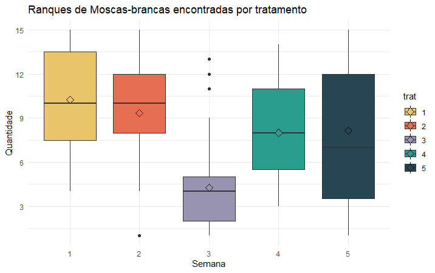

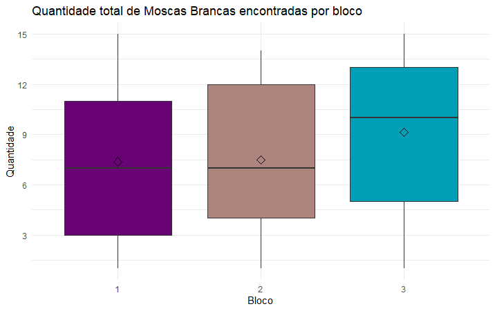

Para a análise dentre os sujeitos não existe o efeito das medidas repetidas, visto que semanalmente todos os ranques variam de 1 a 15. Calculando os p-valores com os graus de liberdade corrigidos, temos:

```r
# semana: trat
1-pf(1.7,gg*32,gg*64)
```

```
## [1] 0.1576293
```

```r
1-pf(1.7,hfl*32,hfl*64)
```

```
## [1] 0.117671
```

```r
#semana:bloco
1-pf(4.776,gg*16,gg*64)
```

```
## [1] 0.006241525
```

```r
1-pf(4.776,hfl*16,hfl*64)
```

```
## [1] 0.001526388
```

Note que com as correções de esfericidade, o p-valor cresceu a ponto de não rejeitar a hipótese nula para interação entre tempo e tratamentos. Portanto, não existem evidências para rejeitar a hipótese de igualdade entre a interação do tempo e dos tratamentos, ou seja, os tratamentos mantém a mesma média de ranks por todo o estudo.

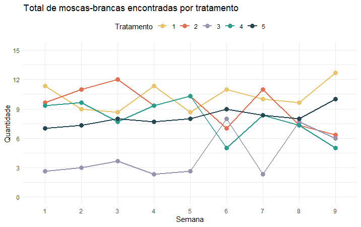

Já a hipótese de igualdade entre a interação dos blocos é rejeitada, portanto existe algum bloco cuja média de ranks muda de forma significativa durante o decorrer do estudo.

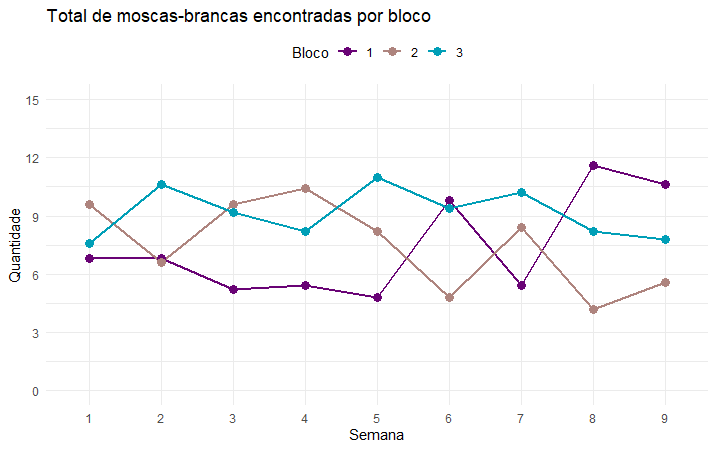

Análise de variância desconsiderando as medidas repetidas:

```r
modelo2 <- aov(rank~trat+bloco)
summary(modelo2)
shapiro.test(modelo2$residuals)
TukeyHSD(modelo2)[1]
scottknott(rank,trat,128,1868.8)
```

```
##              Df Sum Sq Mean Sq F value      Pr(>F)
## trat          4  564.2  141.06   9.661 0.000000735 ***
## bloco         2   87.0   43.49   2.979      0.0544 .
## Residuals   128 1868.8   14.60
## ---
## Signif. codes:  0 '***' 0.001 '**' 0.01 '*' 0.05 '.' 0.1 ' ' 1
##
##  Shapiro-Wilk normality test
##
## data:  modelo2$residuals
## W = 0.98974, p-value = 0.4225
##
## $trat
##           diff        lwr        upr           p adj
## 2-1 -0.9259259 -3.8034988  1.9516470 0.9000089625158
## 3-1 -6.0000000 -8.8775729 -3.1224271 0.0000005618133
## 4-1 -2.2592593 -5.1368322  0.6183137 0.1968564919271
## 5-1 -2.1111111 -4.9886840  0.7664618 0.2577139295056
## 3-2 -5.0740741 -7.9516470 -2.1965012 0.0000303331860
## 4-2 -1.3333333 -4.2109062  1.5442396 0.7026469782387
## 5-2 -1.1851852 -4.0627581  1.6923877 0.7851557648935
## 4-3  3.7407407  0.8631678  6.6183137 0.0041198533390
## 5-3  3.8888889  1.0113160  6.7664618 0.0025293455891
## 5-4  0.1481481 -2.7294248  3.0257211 0.9999061514854
##
##
## Teste de Scott-Knott
## ------------------------------------------------------------------------
##   Grupos Tratamentos    Medias
## 1      a           1 10.259259
## 2      a           2  9.333333
## 3      a           5  8.148148
## 4      a           4  8.000000
## 5      b           3  4.259259
## ------------------------------------------------------------------------
```

Análises de variância por semana e teste subjacentes em caso de significância dos tratamentos:

```r
#Análise de variância por semanas
mod_semana1 <- aov(rank~trat+bloco,data=armadilhas[semana=="1",])
summary(mod_semana1)
shapiro.test(mod_semana1$residuals)
```

```
##             Df Sum Sq Mean Sq F value Pr(>F)
## trat         4  135.3   33.83   2.185  0.161
## bloco        2   20.8   10.40   0.672  0.537
## Residuals    8  123.9   15.48
##
##  Shapiro-Wilk normality test
##
## data:  mod_semana1$residuals
## W = 0.94347, p-value = 0.428
```

```r
mod_semana2 <- aov(rank~trat+bloco,data=armadilhas[semana=="2",])
summary(mod_semana2)
shapiro.test(mod_semana2$residuals)
```

```
##             Df Sum Sq Mean Sq F value Pr(>F)
## trat         4  114.7   28.67   2.002  0.187
## bloco        2   50.8   25.40   1.774  0.230
## Residuals    8  114.5   14.32
##
##  Shapiro-Wilk normality test
##
## data:  mod_semana2$residuals
## W = 0.96146, p-value = 0.7178
```

```r
mod_semana3 <- aov(rank~trat+bloco,data=armadilhas[semana=="3",])
summary(mod_semana3)
shapiro.test(mod_semana3$residuals)
```

```
##             Df Sum Sq Mean Sq F value Pr(>F)
## trat         4  106.0   26.50   1.847  0.213
## bloco        2   59.2   29.60   2.063  0.189
## Residuals    8  114.8   14.35
##
##  Shapiro-Wilk normality test
##
## data:  mod_semana3$residuals
## W = 0.9221, p-value = 0.2074
```

```r
mod_semana4 <- aov(rank~trat+bloco,data=armadilhas[semana=="4",])
summary(mod_semana4)
shapiro.test(mod_semana4$residuals)
```

```
##             Df Sum Sq Mean Sq F value Pr(>F)
## trat         4 140.67   35.17   3.676 0.0554 .
## bloco        2  62.80   31.40   3.282 0.0910 .
## Residuals    8  76.53    9.57
## ---
## Signif. codes:  0 '***' 0.001 '**' 0.01 '*' 0.05 '.' 0.1 ' ' 1
##
##  Shapiro-Wilk normality test
##
## data:  mod_semana4$residuals
## W = 0.93109, p-value = 0.2833
```

```r
mod_semana5 <- aov(rank~trat+bloco,data=armadilhas[semana=="5",])
summary(mod_semana5)
shapiro.test(mod_semana5$residuals)
```

```
##             Df Sum Sq Mean Sq F value Pr(>F)
## trat         4 119.33   29.83   3.714 0.0540 .
## bloco        2  96.40   48.20   6.000 0.0256 *
## Residuals    8  64.27    8.03
## ---
## Signif. codes:  0 '***' 0.001 '**' 0.01 '*' 0.05 '.' 0.1 ' ' 1
##
##  Shapiro-Wilk normality test
##
## data:  mod_semana5$residuals
## W = 0.95311, p-value = 0.5747
```

```r
mod_semana6 <- aov(rank~trat+bloco,data=armadilhas[semana=="6",])
summary(mod_semana6)
shapiro.test(mod_semana6$residuals)
```

```
##             Df Sum Sq Mean Sq F value Pr(>F)
## trat         4   60.0   15.00   0.840  0.537
## bloco        2   77.2   38.60   2.162  0.178
## Residuals    8  142.8   17.85
##
##  Shapiro-Wilk normality test
##
## data:  mod_semana6$residuals
## W = 0.94732, p-value = 0.4833
```

```r
mod_semana7 <- aov(rank~trat+bloco,data=armadilhas[semana=="7",])
summary(mod_semana7)
shapiro.test(mod_semana7$residuals)
```

```
##             Df Sum Sq Mean Sq F value Pr(>F)
## trat         4  136.0   34.00   3.192 0.0761 .
## bloco        2   58.8   29.40   2.761 0.1225
## Residuals    8   85.2   10.65
## ---
## Signif. codes:  0 '***' 0.001 '**' 0.01 '*' 0.05 '.' 0.1 ' ' 1
##
##  Shapiro-Wilk normality test
##
## data:  mod_semana7$residuals
## W = 0.95008, p-value = 0.5258
```

```r
mod_semana8 <- aov(moscab~trat+bloco,data=armadilhas[semana=="8",])
summary(mod_semana8)
shapiro.test(mod_semana8$residuals)
```

```
##             Df   Sum Sq  Mean Sq F value Pr(>F)
## trat         4  1009222   252305   0.084 0.9850
## bloco        2 20181841 10090920   3.359 0.0873 .
## Residuals    8 24030957  3003870
## ---
## Signif. codes:  0 '***' 0.001 '**' 0.01 '*' 0.05 '.' 0.1 ' ' 1
##
##  Shapiro-Wilk normality test
##
## data:  mod_semana8$residuals
## W = 0.95454, p-value = 0.5986
```

```r
mod_semana9 <- aov(moscab~trat+bloco,data=armadilhas[semana=="9",])
summary(mod_semana9)
shapiro.test(mod_semana9$residuals)
```

```
##             Df   Sum Sq Mean Sq F value Pr(>F)
## trat         4 10205951 2551488   2.018  0.185
## bloco        2  5668829 2834414   2.241  0.169
## Residuals    8 10116553 1264569
##
##  Shapiro-Wilk normality test
##
## data:  mod_semana9$residuals
## W = 0.94282, p-value = 0.4191
```

## Dados brutos

Estimativa dos parâmetros do modelo:

```r
m <- 7 #quantidade de medidas repetidas
tapply(moscab,semana,mean)
```

```
##         1         2         3         4         5         6         7
##  5.047619  9.323810  5.609524 16.866667 18.504762 26.371429 39.400000
```

```r
tapply(moscab,semana:trat,mean)-rep(tapply(moscab,semana,mean),each=5)
```

```
##         1:1         1:2         1:3         1:4         1:5         1:6
##   0.4190476  -1.7142857  -3.4476190   0.3523810   7.2857143  -5.7904762
##         1:7         2:1         2:2         2:3         2:4         2:5
##  -5.6571429   2.3428571   1.4761905  -5.5904762   8.3904762   4.3904762
##         2:6         2:7         3:1         3:2         3:3         3:4
##  -1.0761905   4.9238095   1.3904762 -13.4666667 -15.6000000 -10.0666667
##         3:5         3:6         3:7         4:1         4:2         4:3
##  -7.3333333 -14.8666667  -9.2380952   3.0952381 -14.9714286 -16.4380952
##         4:4         4:5         4:6         4:7         5:1         5:2
##  21.7619048   7.8952381 -19.1047619 -17.3047619  -5.7714286 -15.1047619
##         5:3         5:4         5:5         5:6         5:7         6:1
## -36.6000000   3.3333333   2.9333333 -33.6000000 -35.4000000  32.4190476
##         6:2         6:3         6:4         6:5         6:6         6:7
##  32.8190476  -1.9809524  41.4190476  36.6190476  -2.7904762   2.2095238
##         7:1         7:2         7:3         7:4         7:5         7:6
##  75.7428571  16.4761905  -4.7238095  62.8571429  67.8571429   2.4571429
##         7:7
##   4.7238095
```

```r
tapply(moscab,semana:bloco,mean)-rep(tapply(moscab,semana,mean),each=3)
```

```
##         1:1         1:2         1:3         2:1         2:2         2:3
##  -1.8190476   1.0666667   0.7523810  -5.0380952   5.5619048  -0.5238095
##         3:1         3:2         3:3         4:1         4:2         4:3
##  -4.2380952  -1.5238095   5.7619048 -15.4380952   4.8761905  10.5619048
##         5:1         5:2         5:3         6:1         6:2         6:3
## -15.1904762   5.5809524   9.6095238 -18.6857143   4.6857143  14.0000000
##         7:1         7:2         7:3
## -29.9714286  10.0857143  19.8857143
```

Valores preditos e Resíduos (cada coluna indica uma semana):

```r
pred_res <- read.xlsx("/cloud/project/pred_res_plantas.xlsx")
preditos <- pred_res[,c(12:18)]
preditos
```

```
##            pred1 pred2 pred3 pred4        pred5 pred6 pred7
## 1   1.200000e+00   4.2   0.8   4.4 3.000000e+00  19.6  26.6
## 2   1.200000e+00   4.2   0.8   4.4 3.000000e+00  19.6  26.6
## 3   1.200000e+00   4.2   0.8   4.4 3.000000e+00  19.6  26.6
## 4   1.200000e+00   4.2   0.8   4.4 3.000000e+00  19.6  26.6
## 5   1.200000e+00   4.2   0.8   4.4 3.000000e+00  19.6  26.6
## 6   8.000000e+00  21.4   4.0   8.0 7.400000e+00  22.4  87.6
## 7   8.000000e+00  21.4   4.0   8.0 7.400000e+00  22.4  87.6
## 8   8.000000e+00  21.4   4.0   8.0 7.400000e+00  22.4  87.6
## 9   8.000000e+00  21.4   4.0   8.0 7.400000e+00  22.4  87.6
## 10  8.000000e+00  21.4   4.0   8.0 7.400000e+00  22.4  87.6
## 11  7.200000e+00   9.4  16.2  52.4 5.140000e+01  70.4 141.0
## 12  7.200000e+00   9.4  16.2  52.4 5.140000e+01  70.4 141.0
## 13  7.200000e+00   9.4  16.2  52.4 5.140000e+01  70.4 141.0
## 14  7.200000e+00   9.4  16.2  52.4 5.140000e+01  70.4 141.0
```

[output cut: 91 more lines]

```r
residuos <- as.matrix(pred_res[,19:25])
residuos
```

```
##                r1            r2            r3    r4            r5     r6     r7
## 1   -2.000000e-01  1.800000e+00  3.200000e+00   2.6  1.065814e-14   10.4    1.4
## 2   -2.000000e-01 -3.200000e+00 -8.000000e-01  -0.4  1.000000e+00    1.4   43.4
## 3    2.800000e+00  1.800000e+00 -8.000000e-01  -3.4  1.065814e-14    4.4   -4.6
## 4   -1.200000e+00 -4.200000e+00 -8.000000e-01   1.6  1.065814e-14   -4.6  -22.6
## 5   -1.200000e+00  3.800000e+00 -8.000000e-01  -0.4 -1.000000e+00  -11.6  -17.6
## 6    1.776357e-15 -7.400000e+00  3.552714e-15  -2.0  3.600000e+00  -11.4  -83.6
## 7    4.000000e+00  1.460000e+01  1.000000e+00  -4.0 -7.400000e+00   -3.4  -38.6
## 8   -4.000000e+00  4.600000e+00  3.552714e-15   3.0 -3.400000e+00    0.6  -65.6
## 9   -2.000000e+00 -1.340000e+01  1.000000e+00   4.0 -5.400000e+00  -20.4  158.4
## 10   2.000000e+00  1.600000e+00 -2.000000e+00  -1.0  1.260000e+01   34.6   29.4
## 11  -2.200000e+00 -4.400000e+00  4.800000e+00  44.6 -1.140000e+01   93.6   75.0
## 12  -6.200000e+00  6.600000e+00 -1.020000e+01 -10.4  1.360000e+01   -8.4   11.0
## 13   4.800000e+00 -7.400000e+00 -9.200000e+00 -12.4 -3.540000e+01  -51.4  -36.0
## 14   8.000000e-01  6.600000e+00  7.800000e+00 -26.4  7.960000e+01  -42.4   -7.0
```

[output cut: 91 more lines]

```r
S<- t(residuos)%*%residuos #matriz de covariâncias
S
```

```
##         r1      r2      r3       r4       r5       r6       r7
## r1  4354.0   890.8   377.6   3663.4  12331.8  -1560.4  -7392.0
## r2   890.8  5024.4   371.0   5205.4    484.4   1928.4  -6691.2
## r3   377.6   371.0  5502.4   2739.2  -7244.0   3702.0   6832.8
## r4  3663.4  5205.4  2739.2  71783.2 -36089.4 -10004.8  -6925.4
## r5 12331.8   484.4 -7244.0 -36089.4 224445.6 -13132.2 -40904.8
## r6 -1560.4  1928.4  3702.0 -10004.8 -13132.2  93079.6  30022.0
## r7 -7392.0 -6691.2  6832.8  -6925.4 -40904.8  30022.0 240689.2
```

```r
C <- as.matrix(read.xlsx("/cloud/project/contrastes_plantas.xlsx"))
C
```

```
##       semana1    semana2    semana3    semana4    semana5    semana6    semana7
## 1 -0.56694671 -0.3779645 -0.1889822  0.0000000  0.1889822  0.3779645 0.56694671
## 2  0.54554473  0.0000000 -0.3273268 -0.4364358 -0.3273268  0.0000000 0.54554473
## 3 -0.40824829  0.4082483  0.4082483  0.0000000 -0.4082483 -0.4082483 0.40824829
## 4  0.24174689 -0.5640761  0.0805823  0.4834938  0.0805823 -0.5640761 0.24174689
## 5 -0.10910895  0.4364358 -0.5455447  0.0000000  0.5455447 -0.4364358 0.10910895
## 6  0.03289758 -0.1973855  0.4934638 -0.6579517  0.4934638 -0.1973855 0.03289758
```

Cálculo da matriz do teste de Mauschly

```r
CSC <- C%*%S%*%t(C) #Matriz 8x8 para teste de Mauschly
CSC
```

```
##             1          2         3          4          5          6
## 1 107282.1857  81214.815  36848.66   874.7077  -4138.661  13951.867
## 2  81214.8149 104941.719  79367.68  6484.7587 -36783.524 -17767.544
## 3  36848.6584  79367.680 100945.00 34548.0171 -44677.420 -56121.868
## 4    874.7077   6484.759  34548.02 57101.8416  25230.348  -9712.766
## 5  -4138.6612 -36783.524 -44677.42 25230.3478  91028.014  77550.482
## 6  13951.8665 -17767.544 -56121.87 -9712.7655  77550.482 108995.697
```

Teste de esfericidade:

```r
#################### teste de esfericidade

w <- ((m-1)**(m-1))*det(CSC)/(sum(diag(CSC))**(m-1)) #critério de mauschly
w #critério de Mauschly
```

```
## [1] 0.002008814
```

```r
gama <- 84-(2*m**2-3*m+3)/(6*(m-1))
gama
```

```
## [1] 81.77778
```

```r
chi <- -gama*log(w,base=exp(1))
chi
```

```
## [1] 507.8573
```

```r
1-pchisq(chi,(m*(m-1)/2-1))
```

```
## [1] 0
```

```r
################### correções dos graus de liberdade
```

não há esfericidade na matriz de covariâncias estimada. É necessário usar correções ao teste F na análise dentre sujeitos.

Cálculo das correções para os graus de liberdade

```r
gg <- (sum(diag(CSC))**2)/((m-1)*sum((CSC)**2))
gg
```

```
## [1] 0.4727543
```

```r
hfl <- (85*(m-1)*gg-2)/((m-1)*(84-(m-1)*gg))
hfl
```

```
## [1] 0.490994
```

```r
modelo <- aov(moscab ~ trat *bloco * semana + Error(sujeito/semana), data=plantas)
summary(modelo)
```

```
##
## Error: sujeito
##            Df Sum Sq Mean Sq F value   Pr(>F)
## trat        6 102049   17008   19.16 6.14e-14 ***
## bloco       2  63473   31736   35.74 5.87e-12 ***
## trat:bloco 12 265484   22124   24.92  < 2e-16 ***
## Residuals  84  74584     888
## ---
## Signif. codes:  0 '***' 0.001 '**' 0.01 '*' 0.05 '.' 0.1 ' ' 1
##
## Error: sujeito:semana
##                    Df Sum Sq Mean Sq F value   Pr(>F)
## semana              6  96889   16148  14.271 4.77e-15 ***
## trat:semana        36  90594    2517   2.224 8.91e-05 ***
## bloco:semana       12  34722    2893   2.557  0.00272 **
## trat:bloco:semana  72 163415    2270   2.006 8.81e-06 ***
## Residuals         504 570294    1132
## ---
## Signif. codes:  0 '***' 0.001 '**' 0.01 '*' 0.05 '.' 0.1 ' ' 1
```

```r
shapiro.test(residuos)
```

```
##
##  Shapiro-Wilk normality test
##
## data:  residuos
## W = 0.51745, p-value < 2.2e-16
```

```r
scottknott(plantas$moscab,plantas$trat,84,74584,group=T)
```

```
##
## Teste de Scott-Knott
## ------------------------------------------------------------------------
##   Grupos Tratamentos    Medias
## 1      a           4 32.019048
## 2      a           5 31.942857
## 3      a           1 26.980952
## 4      b           2 13.714286
## 5      b           7  8.342857
## 6      b           6  5.390476
## 7      b           3  2.733333
## ------------------------------------------------------------------------
```

Todos os efeitos foram significativos, inclusive a interação entre blocos e tratamentos. Portanto, existe algum tratamento em que a média é diferente das demais. Também existe algum bloco que tem médias diferentes dos demais e o efeito de interação não é nulo pra alguma combinação entre tratamentos e blocos.

Os tratamentos 3, 6 e 7 aparentam ter menores resultados em relação aos outros:

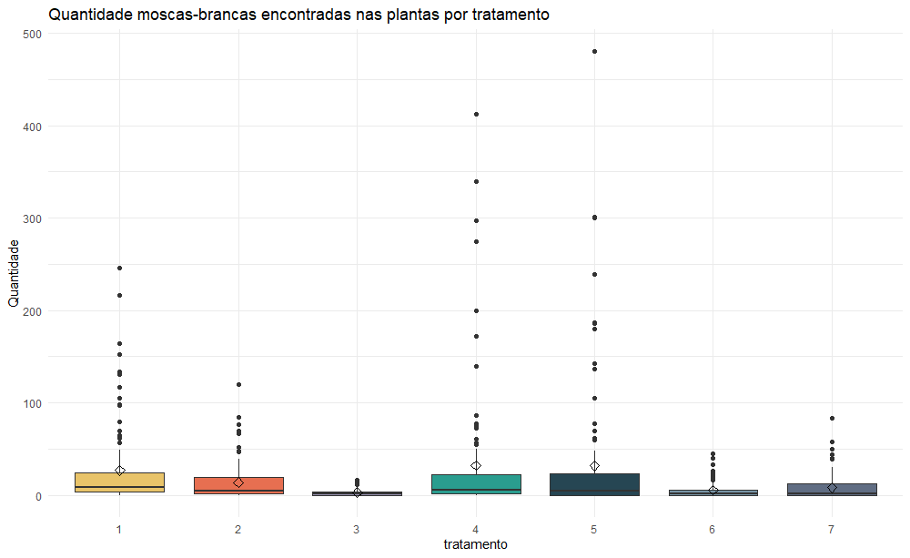

O bloco 1 aparenta ter menor incidência de moscas-brancas:

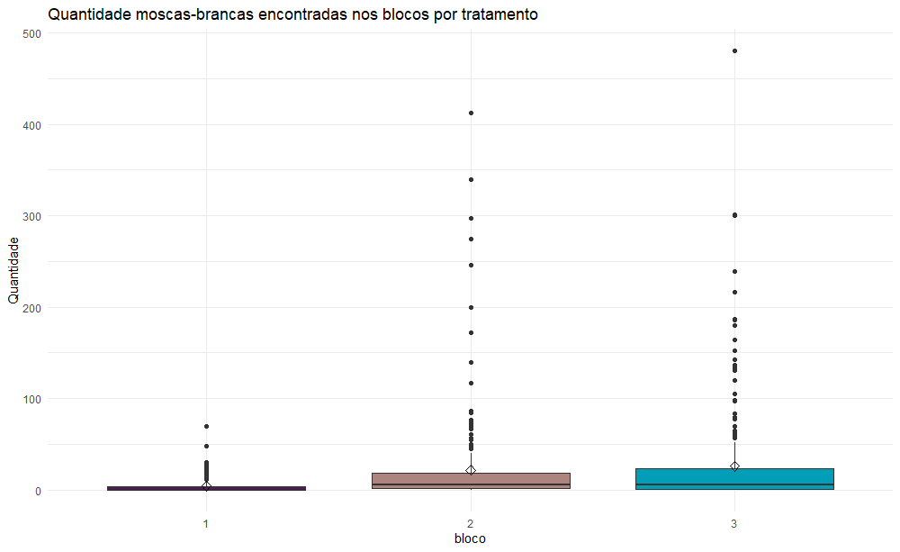

interação tratamento 1 e bloco 3, tratamento 4 e bloco 2 e tratamento 5 e bloco 3 tem maior incidência de moscas brancas.

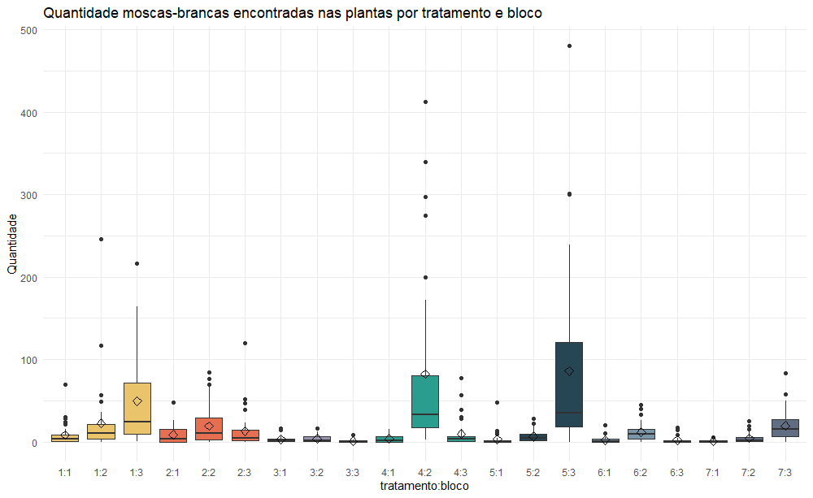

Calculandos os p-valores para a análise dentre os sujeitos com as correções nos graus de liberdade:

```r
#semana
1-pf(14.21,gg*6,gg*504)
1-pf(14.21,hfl*6,hfl*504)
```

```
## [1] 3.110502e-08
## [1] 1.809601e-08
```

Todos os efeitos são significativos com as correções nos graus de liberdade. Portanto, a quantidade de moscas brancas encontradas nas plantas muda significativamente no decorrer do estudo.

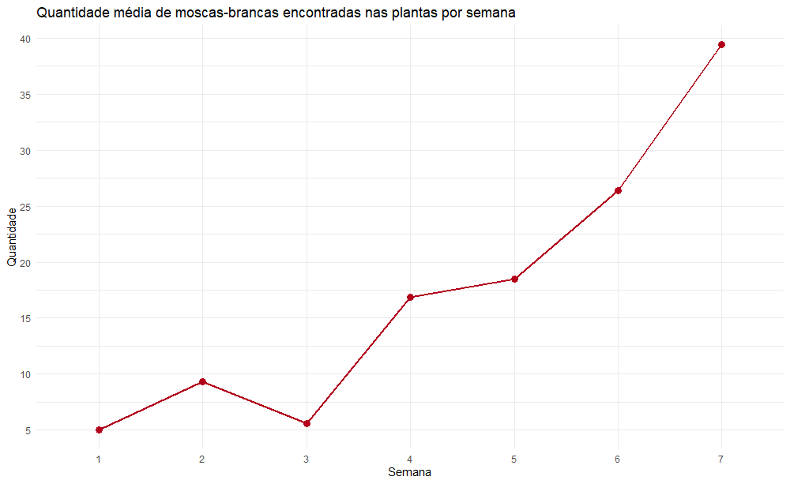

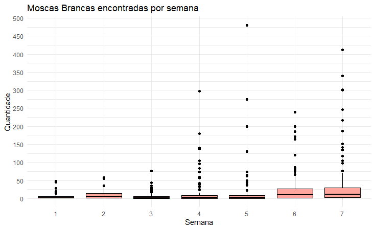

```r
# semana: trat
1-pf(2.224,gg*36,gg*504)
1-pf(2.224,hfl*36,hfl*504)
```

```
## [1] 0.004329352
## [1] 0.00377069
```

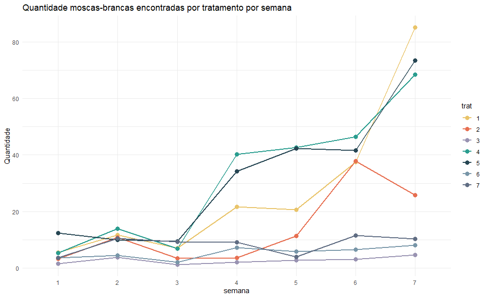

```r
#semana:bloco
1-pf(2.557,gg*12,gg*504)
1-pf(2.557,hfl*12,hfl*504)
```

```
## [1] 0.02258967
## [1] 0.02094253
```

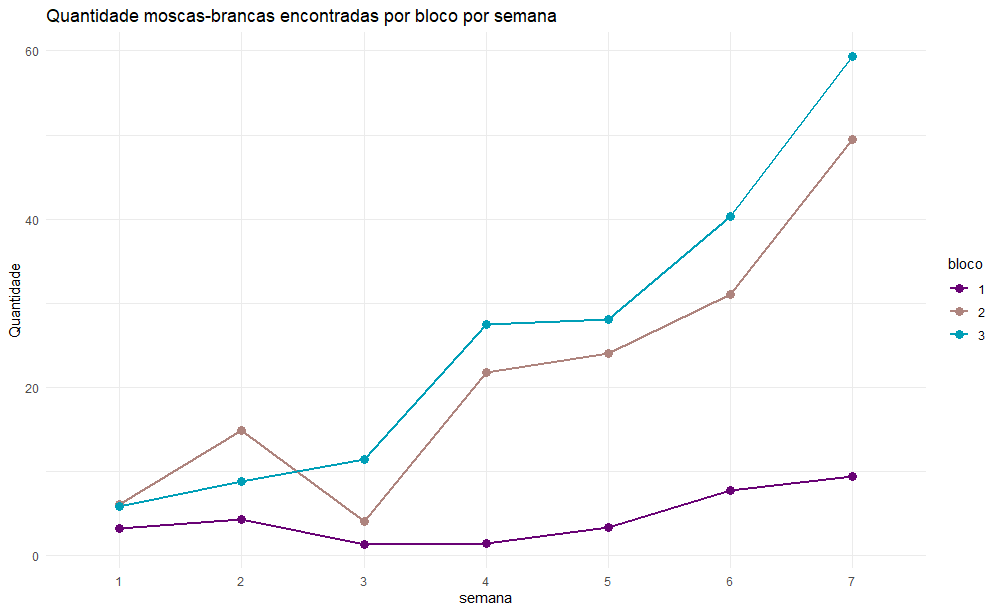

```r
#semana:trat:bloco
1-pf(2.006,gg*72,gg*504)
1-pf(2.006,hfl*72,hfl*504)
```

```
## [1] 0.001432109
## [1] 0.00119557
```

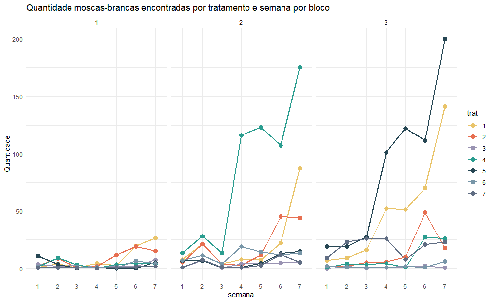

Análise de variância desconsiderando as medidas repetidas:

```r
modelo2 <- aov(moscab~trat*bloco)
summary(modelo2)
shapiro.test(modelo2$residuals)#
TukeyHSD(modelo2)[1]
scottknott(plantas$moscab,plantas$trat,714,1030498)
```

```
##              Df  Sum Sq Mean Sq F value   Pr(>F)
## trat          6  102049   17008   11.78 1.26e-12 ***
## bloco         2   63473   31736   21.99 5.41e-10 ***
## trat:bloco   12  265484   22124   15.33  < 2e-16 ***
## Residuals   714 1030498    1443
## ---
## Signif. codes:  0 '***' 0.001 '**' 0.01 '*' 0.05 '.' 0.1 ' ' 1
##
##  Shapiro-Wilk normality test
##
## data:  modelo2$residuals
## W = 0.56205, p-value < 2.2e-16
##
## $trat
##             diff        lwr        upr           p adj
## 2-1 -13.26666667 -28.769529   2.236196 0.1500457755803
## 3-1 -24.24761905 -39.750482  -8.744756 0.0000907472422
## 4-1   5.03809524 -10.464767  20.540958 0.9620557926830
## 5-1   4.96190476 -10.540958  20.464767 0.9647831739889
## 6-1 -21.59047619 -37.093339  -6.087614 0.0008402289678
## 7-1 -18.63809524 -34.140958  -3.135233 0.0073465596280
## 3-2 -10.98095238 -26.483815   4.521910 0.3570843027854
## 4-2  18.30476190   2.801899  33.807624 0.0091860626614
## 5-2  18.22857143   2.725709  33.731434 0.0096613311696
## 6-2  -8.32380952 -23.826672   7.179053 0.6904378704808
## 7-2  -5.37142857 -20.874291  10.131434 0.9483618178457
## 4-3  29.28571429  13.782852  44.788577 0.0000006884193
## 5-3  29.20952381  13.706661  44.712386 0.0000007459429
## 6-3   2.65714286 -12.845720  18.160005 0.9987640466755
## 7-3   5.60952381  -9.893339  21.112386 0.9367241512924
## 5-4  -0.07619048 -15.579053  15.426672 0.9999999999992
## 6-4 -26.62857143 -42.131434 -11.125709 0.0000100441223
## 7-4 -23.67619048 -39.179053  -8.173328 0.0001495557646
## 6-5 -26.55238095 -42.055244 -11.049518 0.0000108088065
## 7-5 -23.60000000 -39.102863  -8.097137 0.0001597207046
## 7-6   2.95238095 -12.550482  18.455244 0.9977616661595
##
##
## Teste de Scott-Knott
## ------------------------------------------------------------------------
##   Grupos Tratamentos    Medias
## 1      a           4 32.019048
## 2      a           5 31.942857
## 3      a           1 26.980952
## 4      b           2 13.714286
## 5      b           7  8.342857
## 6      b           6  5.390476
## 7      b           3  2.733333
## ------------------------------------------------------------------------
```

Análises de variância por semana e teste subjacentes em caso de significância dos tratamentos:

```r
#Análise de variância por semanas
mod_semana1 <- aov(moscab~trat*bloco,data=plantas[semana=="1",])
summary(mod_semana1)
shapiro.test(mod_semana1$residuals)
TukeyHSD(mod_semana1)[1]
scottknott(plantas$moscab[semana=="1"],plantas$trat[semana=="1"],84,4354)
```

```
##             Df Sum Sq Mean Sq F value  Pr(>F)
## trat         6   1086  181.02   3.492 0.00393 **
## bloco        2    175   87.72   1.692 0.19029
## trat:bloco  12   1261  105.10   2.028 0.03135 *
## Residuals   84   4354   51.83
## ---
## Signif. codes:  0 '***' 0.001 '**' 0.01 '*' 0.05 '.' 0.1 ' ' 1
##
##  Shapiro-Wilk normality test
##
## data:  mod_semana1$residuals
## W = 0.77096, p-value = 1.684e-11
##
## $trat
##            diff        lwr        upr       p adj
## 2-1 -2.13333333 -10.075140  5.8084729 0.983177068
## 3-1 -3.86666667 -11.808473  4.0751395 0.761063729
## 4-1 -0.06666667  -8.008473  7.8751395 1.000000000
## 5-1  6.86666667  -1.075140 14.8084729 0.135542240
## 6-1 -1.93333333  -9.875140  6.0084729 0.989936121
## 7-1 -1.80000000  -9.741806  6.1418062 0.993126790
## 3-2 -1.73333333  -9.675140  6.2084729 0.994394541
## 4-2  2.06666667  -5.875140 10.0084729 0.985723475
## 5-2  9.00000000   1.058194 16.9418062 0.016029859
## 6-2  0.20000000  -7.741806  8.1418062 0.999999982
## 7-2  0.33333333  -7.608473  8.2751395 0.999999624
## 4-3  3.80000000  -4.141806 11.7418062 0.775475207
## 5-3 10.73333333   2.791527 18.6751395 0.001886986
## 6-3  1.93333333  -6.008473  9.8751395 0.989936121
## 7-3  2.06666667  -5.875140 10.0084729 0.985723475
## 5-4  6.93333333  -1.008473 14.8751395 0.128069862
## 6-4 -1.86666667  -9.808473  6.0751395 0.991647955
## 7-4 -1.73333333  -9.675140  6.2084729 0.994394541
## 6-5 -8.80000000 -16.741806 -0.8581938 0.020089939
## 7-5 -8.66666667 -16.608473 -0.7248605 0.023290453
## 7-6  0.13333333  -7.808473  8.0751395 0.999999998
##
##
## Teste de Scott-Knott
## ------------------------------------------------------------------------
##   Grupos Tratamentos    Medias
## 1      a           5 12.333333
## 2      b           1  5.466667
## 3      b           4  5.400000
## 4      b           7  3.666667
## 5      b           6  3.533333
## 6      b           2  3.333333
## 7      b           3  1.600000
## ------------------------------------------------------------------------
```

```r
mod_semana2 <- aov(moscab~trat*bloco,data=plantas[semana=="2",])
summary(mod_semana2)
shapiro.test(mod_semana2$residuals)
TukeyHSD(mod_semana1)[1]
scottknott(plantas$moscab[semana=="2"],plantas$trat[semana=="2"],84,5024)
```

```
##             Df Sum Sq Mean Sq F value      Pr(>F)
## trat         6   1285   214.1   3.580      0.0033 **
## bloco        2   1981   990.4  16.557 0.000000867 ***
## trat:bloco  12   3831   319.3   5.337 0.000001254 ***
## Residuals   84   5024    59.8
## ---
## Signif. codes:  0 '***' 0.001 '**' 0.01 '*' 0.05 '.' 0.1 ' ' 1
##
##  Shapiro-Wilk normality test
##
## data:  mod_semana2$residuals
## W = 0.86674, p-value = 2.901e-08
##
## $trat
##            diff        lwr        upr       p adj
## 2-1 -2.13333333 -10.075140  5.8084729 0.983177068
## 3-1 -3.86666667 -11.808473  4.0751395 0.761063729
## 4-1 -0.06666667  -8.008473  7.8751395 1.000000000
## 5-1  6.86666667  -1.075140 14.8084729 0.135542240
## 6-1 -1.93333333  -9.875140  6.0084729 0.989936121
## 7-1 -1.80000000  -9.741806  6.1418062 0.993126790
## 3-2 -1.73333333  -9.675140  6.2084729 0.994394541
## 4-2  2.06666667  -5.875140 10.0084729 0.985723475
## 5-2  9.00000000   1.058194 16.9418062 0.016029859
## 6-2  0.20000000  -7.741806  8.1418062 0.999999982
## 7-2  0.33333333  -7.608473  8.2751395 0.999999624
## 4-3  3.80000000  -4.141806 11.7418062 0.775475207
## 5-3 10.73333333   2.791527 18.6751395 0.001886986
## 6-3  1.93333333  -6.008473  9.8751395 0.989936121
## 7-3  2.06666667  -5.875140 10.0084729 0.985723475
## 5-4  6.93333333  -1.008473 14.8751395 0.128069862
## 6-4 -1.86666667  -9.808473  6.0751395 0.991647955
## 7-4 -1.73333333  -9.675140  6.2084729 0.994394541
## 6-5 -8.80000000 -16.741806 -0.8581938 0.020089939
## 7-5 -8.66666667 -16.608473 -0.7248605 0.023290453
## 7-6  0.13333333  -7.808473  8.0751395 0.999999998
##
##
## Teste de Scott-Knott
## ------------------------------------------------------------------------
##   Grupos Tratamentos    Medias
## 1      a           4 14.000000
## 2      a           1 11.666667
## 3      a           2 10.800000
## 4      a           7 10.533333
## 5      a           5 10.000000
## 6      b           6  4.533333
## 7      b           3  3.733333
## ------------------------------------------------------------------------
```

```r
mod_semana3 <- aov(moscab~trat*bloco,data=plantas[semana=="3",])
summary(mod_semana3)
shapiro.test(mod_semana3$residuals)
TukeyHSD(mod_semana1)[1]
scottknott(plantas$moscab[semana=="3"],plantas$trat[semana=="3"],84,5502)
```

```
##             Df Sum Sq Mean Sq F value     Pr(>F)
## trat         6   1033   172.2   2.629     0.0219 *
## bloco        2   1872   936.0  14.288 0.00000456 ***
## trat:bloco  12   3725   310.4   4.739 0.00000730 ***
## Residuals   84   5502    65.5
## ---
## Signif. codes:  0 '***' 0.001 '**' 0.01 '*' 0.05 '.' 0.1 ' ' 1
##
##  Shapiro-Wilk normality test
##
## data:  mod_semana3$residuals
## W = 0.67547, p-value = 6.574e-14
##
## $trat
##            diff        lwr        upr       p adj
## 2-1 -2.13333333 -10.075140  5.8084729 0.983177068
## 3-1 -3.86666667 -11.808473  4.0751395 0.761063729
## 4-1 -0.06666667  -8.008473  7.8751395 1.000000000
## 5-1  6.86666667  -1.075140 14.8084729 0.135542240
## 6-1 -1.93333333  -9.875140  6.0084729 0.989936121
## 7-1 -1.80000000  -9.741806  6.1418062 0.993126790
## 3-2 -1.73333333  -9.675140  6.2084729 0.994394541
## 4-2  2.06666667  -5.875140 10.0084729 0.985723475
## 5-2  9.00000000   1.058194 16.9418062 0.016029859
## 6-2  0.20000000  -7.741806  8.1418062 0.999999982
## 7-2  0.33333333  -7.608473  8.2751395 0.999999624
## 4-3  3.80000000  -4.141806 11.7418062 0.775475207
## 5-3 10.73333333   2.791527 18.6751395 0.001886986
## 6-3  1.93333333  -6.008473  9.8751395 0.989936121
## 7-3  2.06666667  -5.875140 10.0084729 0.985723475
## 5-4  6.93333333  -1.008473 14.8751395 0.128069862
## 6-4 -1.86666667  -9.808473  6.0751395 0.991647955
## 7-4 -1.73333333  -9.675140  6.2084729 0.994394541
## 6-5 -8.80000000 -16.741806 -0.8581938 0.020089939
## 7-5 -8.66666667 -16.608473 -0.7248605 0.023290453
## 7-6  0.13333333  -7.808473  8.0751395 0.999999998
##
##
## Teste de Scott-Knott
## ------------------------------------------------------------------------
##   Grupos Tratamentos   Medias
## 1      a           5 9.533333
## 2      a           7 9.266667
## 3      a           1 7.000000
## 4      a           4 6.800000
## 5      b           2 3.400000
## 6      b           6 2.000000
## 7      b           3 1.266667
## ------------------------------------------------------------------------
```

```r
mod_semana4 <- aov(moscab~trat*bloco,data=plantas[semana=="4",])
summary(mod_semana4)
shapiro.test(mod_semana4$residuals) # trat significativo
TukeyHSD(mod_semana4)[1]
scottknott(plantas$moscab[semana=="4"],plantas$trat[semana=="4"],84,71783)
```

```
##             Df Sum Sq Mean Sq F value   Pr(>F)
## trat         6  21338    3556   4.162 0.001039 **
## bloco        2  13078    6539   7.652 0.000885 ***
## trat:bloco  12  74338    6195   7.249 6.36e-09 ***
## Residuals   84  71783     855
## ---
## Signif. codes:  0 '***' 0.001 '**' 0.01 '*' 0.05 '.' 0.1 ' ' 1
##
##  Shapiro-Wilk normality test
##
## data:  mod_semana4$residuals
## W = 0.54204, p-value < 2.2e-16
##
## $trat
##           diff          lwr        upr       p adj
## 2-1 -18.066667 -50.31345601 14.1801227 0.622869893
## 3-1 -19.533333 -51.78012268 12.7134560 0.532026953
## 4-1  18.666667 -13.58012268 50.9134560 0.585789778
## 5-1  12.666667 -19.58012268 44.9134560 0.897305873
## 6-1 -14.333333 -46.58012268 17.9134560 0.829685478
## 7-1 -12.533333 -44.78012268 19.7134560 0.901878730
## 3-2  -1.466667 -33.71345601 30.7801227 0.999999392
## 4-2  36.733333   4.48654399 68.9801227 0.015195253
## 5-2  30.733333  -1.51345601 62.9801227 0.072034141
## 6-2   3.733333 -28.51345601 35.9801227 0.999845950
## 7-2   5.533333 -26.71345601 37.7801227 0.998521002
## 4-3  38.200000   5.95321065 70.4467893 0.009968944
## 5-3  32.200000  -0.04678935 64.4467893 0.050582381
## 6-3   5.200000 -27.04678935 37.4467893 0.998959480
## 7-3   7.000000 -25.24678935 39.2467893 0.994556836
## 5-4  -6.000000 -38.24678935 26.2467893 0.997670908
## 6-4 -33.000000 -65.24678935 -0.7532107 0.041392742
## 7-4 -31.200000 -63.44678935  1.0467893 0.064500022
## 6-5 -27.000000 -59.24678935  5.2467893 0.162214704
## 7-5 -25.200000 -57.44678935  7.0467893 0.228451652
## 7-6   1.800000 -30.44678935 34.0467893 0.999997936
##
##
## Teste de Scott-Knott
## ------------------------------------------------------------------------
##   Grupos Tratamentos    Medias
## 1      a           4 40.266667
## 2      a           5 34.266667
## 3      a           1 21.600000
## 4      b           7  9.066667
## 5      b           6  7.266667
## 6      b           2  3.533333
## 7      b           3  2.066667
## ------------------------------------------------------------------------
```

```r
mod_semana5 <- aov(moscab~trat*bloco,data=plantas[semana=="5",])
summary(mod_semana5)
shapiro.test(mod_semana5$residuals)
```

```
##             Df Sum Sq Mean Sq F value Pr(>F)
## trat         6  27451    4575   1.712 0.1281
## bloco        2  12398    6199   2.320 0.1045
## trat:bloco  12  92192    7683   2.875 0.0023 **
## Residuals   84 224446    2672
## ---
## Signif. codes:  0 '***' 0.001 '**' 0.01 '*' 0.05 '.' 0.1 ' ' 1
##
##  Shapiro-Wilk normality test
##
## data:  mod_semana5$residuals
## W = 0.48614, p-value < 2.2e-16
```

```r
mod_semana6 <- aov(moscab~trat*bloco,data=plantas[semana=="6",])
summary(mod_semana6)
shapiro.test(mod_semana6$residuals)
TukeyHSD(mod_semana6)[1]
scottknott(plantas$moscab[semana=="6"],plantas$trat[semana=="6"],84,93080)
```

```
##             Df Sum Sq Mean Sq F value    Pr(>F)
## trat         6  30748    5125   4.625  0.000417 ***
## bloco        2  19849    9924   8.956  0.000298 ***
## trat:bloco  12  58218    4852   4.378 0.0000217 ***
## Residuals   84  93080    1108
## ---
## Signif. codes:  0 '***' 0.001 '**' 0.01 '*' 0.05 '.' 0.1 ' ' 1
##
##  Shapiro-Wilk normality test
##
## data:  mod_semana6$residuals
## W = 0.78564, p-value = 4.521e-11
##
## $trat
##           diff        lwr       upr      p adj
## 2-1   0.400000 -36.319971 37.119971 1.00000000
## 3-1 -34.400000 -71.119971  2.319971 0.08135882
## 4-1   9.000000 -27.719971 45.719971 0.98956790
## 5-1   4.200000 -32.519971 40.919971 0.99985647
## 6-1 -30.933333 -67.653304  5.786637 0.15693963
## 7-1 -25.933333 -62.653304 10.786637 0.34308529
## 3-2 -34.800000 -71.519971  1.919971 0.07500242
## 4-2   8.600000 -28.119971 45.319971 0.99180571
## 5-2   3.800000 -32.919971 40.519971 0.99992010
## 6-2 -31.333333 -68.053304  5.386637 0.14614604
## 7-2 -26.333333 -63.053304 10.386637 0.32477475
## 4-3  43.400000   6.680029 80.119971 0.01022534
## 5-3  38.600000   1.880029 75.319971 0.03284840
## 6-3   3.466667 -33.253304 40.186637 0.99995342
## 7-3   8.466667 -28.253304 45.186637 0.99246289
## 5-4  -4.800000 -41.519971 31.919971 0.99968804
## 6-4 -39.933333 -76.653304 -3.213363 0.02406753
## 7-4 -34.933333 -71.653304  1.786637 0.07297812
## 6-5 -35.133333 -71.853304  1.586637 0.07002772
## 7-5 -30.133333 -66.853304  6.586637 0.18030624
## 7-6   5.000000 -31.719971 41.719971 0.99960503
##
##
## Teste de Scott-Knott
## ------------------------------------------------------------------------
##   Grupos Tratamentos    Medias
## 1      a           4 46.466667
## 2      a           5 41.666667
## 3      a           2 37.866667
## 4      a           1 37.466667
## 5      b           7 11.533333
## 6      b           6  6.533333
## 7      b           3  3.066667
## ------------------------------------------------------------------------
```

```r
mod_semana7 <- aov(moscab~trat*bloco,data=plantas[semana=="7",])
summary(mod_semana7)
shapiro.test(mod_semana7$residuals)
TukeyHSD(mod_semana6)[1]
scottknott(plantas$moscab[semana=="7"],plantas$trat[semana=="7"],84,240689)
```

```
##             Df Sum Sq Mean Sq F value      Pr(>F)
## trat         6 109703   18284   6.381 0.000014499 ***
## bloco        2  48841   24420   8.523    0.000427 ***
## trat:bloco  12 195333   16278   5.681 0.000000466 ***
## Residuals   84 240689    2865
## ---
## Signif. codes:  0 '***' 0.001 '**' 0.01 '*' 0.05 '.' 0.1 ' ' 1
##
##  Shapiro-Wilk normality test
##
## data:  mod_semana7$residuals
## W = 0.72286, p-value = 8.72e-13
##
## $trat
##           diff        lwr       upr      p adj
## 2-1   0.400000 -36.319971 37.119971 1.00000000
## 3-1 -34.400000 -71.119971  2.319971 0.08135882
## 4-1   9.000000 -27.719971 45.719971 0.98956790
## 5-1   4.200000 -32.519971 40.919971 0.99985647
## 6-1 -30.933333 -67.653304  5.786637 0.15693963
## 7-1 -25.933333 -62.653304 10.786637 0.34308529
## 3-2 -34.800000 -71.519971  1.919971 0.07500242
## 4-2   8.600000 -28.119971 45.319971 0.99180571
## 5-2   3.800000 -32.919971 40.519971 0.99992010
## 6-2 -31.333333 -68.053304  5.386637 0.14614604
## 7-2 -26.333333 -63.053304 10.386637 0.32477475
## 4-3  43.400000   6.680029 80.119971 0.01022534
## 5-3  38.600000   1.880029 75.319971 0.03284840
## 6-3   3.466667 -33.253304 40.186637 0.99995342
## 7-3   8.466667 -28.253304 45.186637 0.99246289
## 5-4  -4.800000 -41.519971 31.919971 0.99968804
## 6-4 -39.933333 -76.653304 -3.213363 0.02406753
## 7-4 -34.933333 -71.653304  1.786637 0.07297812
## 6-5 -35.133333 -71.853304  1.586637 0.07002772
## 7-5 -30.133333 -66.853304  6.586637 0.18030624
## 7-6   5.000000 -31.719971 41.719971 0.99960503
##
##
## Teste de Scott-Knott
## ------------------------------------------------------------------------
##   Grupos Tratamentos    Medias
## 1      a           1 85.066667
## 2      a           5 73.466667
## 3      a           4 68.466667
## 4      b           2 25.800000
## 5      b           7 10.333333
## 6      b           6  8.066667
## 7      b           3  4.600000
## ------------------------------------------------------------------------
```